# Merging and cleaning stomach data from different sources

Max Lindmark

28 November, 2022

**Data to merge:** Stomach data, biological data and trawl data When preparing (standardizing, filtering, expanding, merging) these data, there are a few things to know:

1. Column names: Even though the data format *should* in theory be fairly standardized already, there are many differences in column names. Some of them are due to different spelling, some are just different. Like predator ID, sometimes it’s sample, sometimes it’s otolith ID, for instance.
2. Coordinates: Stomach data needs to be joined with trawl data to get the spatial location of the stomach. This is done by creating a unique haul ID. However, due to missing values in the columns that make up the ID, we are not able to link all stomach data to a haul
3. Empty stomachs: empty stomach is indicated by a column. However, this is not fool proof (no column in these data are 100% without missing information), since I get slightly different proportions of empty stomachs when manually calculating the proportion of predator ID’s with a total count of prey weight = 0. This is in cases when prey_latin_name or prey_sp_code == NA and/or prey_weight is NA and there is only a single row for that predator ID.
4. One row = One prey: The data has a column indicating the number of prey that specific row corresponds to, so I need to repeat that row X times to get one row = one prey.

In addition to these points, there are numerous small little fixes and quality checks here and there (e.g., filtering impossible prey sizes etc.)

## First load packages

```r
# options(max.print = 5000)
# Load libraries, install if needed
library(tidyverse)
library(readxl)
library(tidylog)
library(RCurl)
library(RColorBrewer)
```

```r
library(patchwork)
library(janitor)
library(mapplots)
library(rnaturalearth)
library(rnaturalearthdata)
library(forcats)
library(gapminder)
library(viridis)
library(ggridges)
library(raster)
library(icesDatras)
library(raster)
library(sp)

# Source UTM function
source("/Users/maxlindmark/Dropbox/Max work/R/cod_interactions/R/functions/lon_lat_utm.R")

# Source code for map plots
source("/Users/maxlindmark/Dropbox/Max work/R/cod_interactions/R/functions/map_plot.R")

theme_set(theme_plot())

world <- ne_countries(scale = "medium", returnclass = "sf")

xlim <- c(8, 22)
ylim <- c(54, 60)
```

# Load stomach, biological and trawl data

## Stomach

```r
# Flounder
bits_2015_q4_fle <- readxl::read_xls("data/stomach_data/BITS/stomach/2017-10-31_database_COD_FLE_part_2_Kevin.xls", sheet = 3) %>%
  mutate(Year = 2015) %>%
  clean_names()

bits_2016_q1_fle <- readxl::read_xls("data/stomach_data/BITS/stomach/2017-10-31_database_COD_FLE_part_2_Kevin.xls", sheet = 4) %>%
  clean_names()

bits_2016_q4_fle <- readxl::read_xls("data/stomach_data/BITS/stomach/2017-10-31_database_COD_FLE_part_2_Kevin.xls", sheet = 5) %>%
  clean_names()

bits_2017_q1_fle <- readxl::read_xlsx("data/stomach_data/BITS/stomach/02.01.2019_database_COD_FLE.xlsx", sheet = 1) %>%
  clean_names()

bits_2017_q4_fle <- readxl::read_xlsx("data/stomach_data/BITS/stomach/02.01.2019_database_COD_FLE.xlsx", sheet = 2) %>%
  clean_names() %>%
  mutate(year = 2017)

bits_2018_q1_fle <- readxl::read_xlsx("data/stomach_data/BITS/stomach/database_22.12.2019_part 2.xlsx", sheet = 2) %>%
  clean_names()

bits_2019_q4_fle <- readxl::read_xlsx("data/stomach_data/BITS/stomach/!database_2020_SWE.xlsx", sheet = 4) %>%
  clean_names()

bits_2020_q1_fle <- readxl::read_xlsx("data/stomach_data/BITS/stomach/!database_2020_SWE.xlsx", sheet = 5) %>%
  clean_names()
# Cod
bits_2015_q4_cod <- readxl::read_xls("data/stomach_data/BITS/stomach/2017-06-29_database_COD_part_1_Kevin.xls", sheet = 1) %>%
  clean_names()

bits_2016_q1_cod <- readxl::read_xls("data/stomach_data/BITS/stomach/2017-06-29_database_COD_part_1_Kevin.xls", sheet = 2) %>%
  clean_names()

# This q-year combo was sent in two batches
bits_2016_q1_cod_v2 <- readxl::read_xlsx("data/stomach_data/BITS/stomach/28.12.2018_database_COD.xlsx", sheet = 1) %>%
  clean_names()

bits_2016_q4_cod <- readxl::read_xls("data/stomach_data/BITS/stomach/2017-10-31_database_COD_FLE_part_2_Kevin.xls", sheet = 6) %>%
  clean_names()

bits_2017_q1_cod <- readxl::read_xlsx("data/stomach_data/BITS/stomach/28.12.2018_database_COD.xlsx", sheet = 2) %>%
  clean_names() %>%
  mutate(predator_code = "COD")

bits_2017_q4_cod <- readxl::read_xlsx("data/stomach_data/BITS/stomach/28.12.2018_database_COD.xlsx", sheet = 3) %>%
  clean_names()

bits_2018_q1_cod <- readxl::read_xlsx("data/stomach_data/BITS/stomach/9.07.2019_database_part 1.xlsx", sheet = 2) %>%
  clean_names()

bits_2018_q4_cod <- readxl::read_xlsx("data/stomach_data/BITS/stomach/database_22.12.2019_part 2.xlsx", sheet = 1) %>%
  clean_names()

bits_2019_q4_cod <- readxl::read_xlsx("data/stomach_data/BITS/stomach/!database_2020_SWE.xlsx", sheet = 2) %>%
  clean_names()

bits_2020_q1_cod <- readxl::read_xlsx("data/stomach_data/BITS/stomach/!database_2020_SWE.xlsx", sheet = 3) %>%
  clean_names() %>%
  mutate(quarter = 1,
         predator_code = "COD")

# Bind them together, then see what columns are missing from the base data
colnames(bits_2015_q4_fle)
colnames(bits_2016_q1_fle)
colnames(bits_2016_q4_fle)
colnames(bits_2017_q1_fle)
colnames(bits_2017_q4_fle)
colnames(bits_2018_q1_fle)
colnames(bits_2019_q4_fle)
colnames(bits_2020_q1_fle)

colnames(bits_2015_q4_cod)
colnames(bits_2016_q1_cod)
colnames(bits_2016_q1_cod_v2)
colnames(bits_2017_q1_cod)
colnames(bits_2017_q4_cod)
colnames(bits_2018_q1_cod)
colnames(bits_2018_q4_cod)
colnames(bits_2019_q4_cod)
colnames(bits_2020_q1_cod)

# Looks like we have to bind_rows them and clean column names afterwards since they don't match...
stom <- bind_rows(bits_2015_q4_fle %>% mutate(hn = as.character(hn),
                                              sample_12 = as.character(sample_12)),
                  bits_2016_q1_fle,
                  bits_2016_q4_fle %>% mutate(prey_weight = as.numeric(prey_weight),
                                              sample_12 = as.character(sample_12)),
                  bits_2017_q1_fle %>% mutate(hn = as.character(hn)),
                  bits_2017_q4_fle %>% mutate(hn = as.character(hn),
                                              parasites_in_stomach = as.character(parasites_in_stomach)),
                  bits_2018_q1_fle,
                  bits_2019_q4_fle %>% mutate(parasites_in_stomach = as.character(parasites_in_stomach)),
                  bits_2020_q1_fle %>% mutate(hn = as.character(hn),
                                              sample = as.character(sample)),
                  bits_2015_q4_cod %>% mutate(hn = as.character(hn),
                                              parasites_in_stomach = as.character(parasites_in_stomach),
                                              predator_gutted_weight = as.numeric(predator_gutted_weight),
                                              maturity = as.numeric(maturity)),
                  bits_2016_q1_cod %>% mutate(sample_1 = as.character(sample_1),
                                              sample_12 = as.character(sample_12),
                                              hn = as.character(hn),
                                              parasites_in_stomach = as.character(parasites_in_stomach),
                                              predator_gutted_weight = as.numeric(predator_gutted_weight),
                                              maturity = as.numeric(maturity)),
                  bits_2016_q1_cod_v2 %>% mutate(hn = as.character(hn),
                                                 stomach_state = as.character(stomach_state)),
                  bits_2017_q1_cod %>% mutate(stomach_state = as.character(stomach_state),
                                              gall_bladder = as.character(gall_bladder)),
                  bits_2017_q4_cod %>% mutate(hn = as.character(hn),
                                              stomach_state = as.character(stomach_state),
                                              gall_bladder = as.character(gall_bladder)),
                  bits_2018_q1_cod %>% mutate(hn = as.character(hn),
                                              sample = as.character(sample)),
                  bits_2018_q4_cod %>% mutate(hn = as.character(hn),
                                              gall_bladder = as.character(gall_bladder)),
                  bits_2019_q4_cod %>% mutate(hn = as.character(hn),
                                              parasites_in_stomach = as.character(parasites_in_stomach),
                                              sample = as.character(sample),
                                              gall_bladder = as.character(gall_bladder)),
                  bits_2020_q1_cod %>% mutate(hn = as.character(hn),
                                              parasites_in_stomach = as.character(parasites_in_stomach),
                                              stomach_state = as.character(stomach_state),
                                              sample = as.character(sample),
                                              gall_bladder = as.character(gall_bladder))
                  )



```

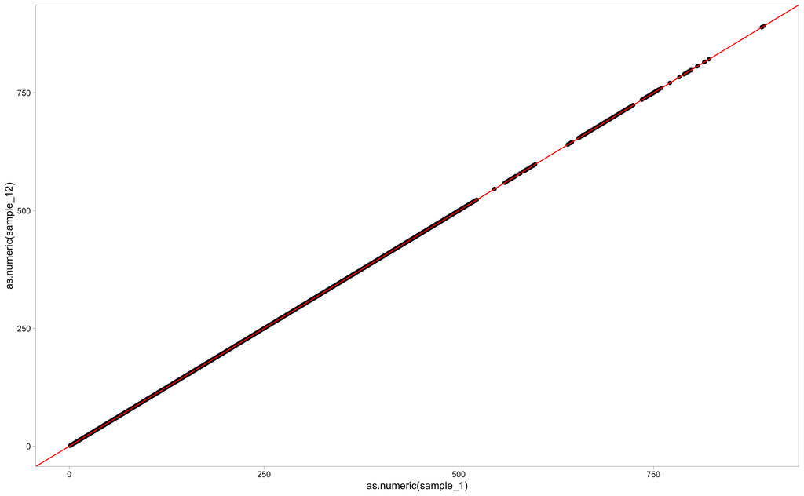

```r
# Now fix the "sample" column. It's sometimes sample, sample_1, sometimes sample_12
stom <- stom %>%
  mutate(data_id = paste(year, quarter, predator_code, sep = "_"))

stom %>%
  summarise(sample_na = unique(is.na(sample)),
            sample_1_na = unique(is.na(sample_1)),
            sample_12_na = unique(is.na(sample_12))) %>%
  ungroup() %>%
  mutate(sample_na = ifelse(sample_na == "FALSE", 1, 0),
         sample_1_na = ifelse(sample_1_na == "FALSE", 1, 0),
         sample_12_na = ifelse(sample_12_na == "FALSE", 1, 0),
         sum = sample_na + sample_1_na + sample_12_na) %>%
  as.data.frame()

# Ok, most data have either/or, but some have multiple and some have 0....
unique(is.na(bits_2020_q1_fle$sample))

bits_2020_q1_fle %>% drop_na(sample)
bits_2016_q4_fle %>% drop_na(sample_1)
bits_2016_q4_fle %>% drop_na(sample_12)

# The zeroes simply have no sample, not too many rows though... What about the multiple ones?
stom %>%
  mutate(sample_na = ifelse(is.na(sample), 1, 0),
         sample_1_na = ifelse(is.na(sample_1), 1, 0),
         sample_12_na = ifelse(is.na(sample_12), 1, 0),
         sum = sample_na + sample_1_na + sample_12_na) %>%
  group_by(data_id) %>%
  summarise(sum2 = median(sum)) %>%
  ungroup() %>%
  as.data.frame()

stom %>%
  mutate(sample_na = ifelse(is.na(sample), 0, 1),
         sample_1_na = ifelse(is.na(sample_1), 0, 1),
         sample_12_na = ifelse(is.na(sample_12), 0, 1),
         sum = sample_na + sample_1_na + sample_12_na) %>%
  filter(sum > 1) %>%
  as.data.frame() %>%
  ggplot(aes(as.numeric(sample_1), as.numeric(sample_12))) +
  geom_point() +
  geom_abline(color = "red", size = 0.5)


```

```r
# Ok, so sample_1 and sample_12 are the same. They get the appendix because there are duplicate columns. This is also verified in a excel file. Rename!
stom <- stom %>%
  mutate(sample = ifelse(is.na(sample), sample_1, sample),
         sample = ifelse(is.na(sample), sample_12, sample)) %>%
  drop_na(sample) %>%
  dplyr::select(-sample_1, -sample_12)

colnames(stom)
str(stom)

# column "sqare" a typo
stom <- stom %>%
  mutate(square = ifelse(is.na(square), sqare, square)) %>%
  dplyr::select(-sqare)

# Good for now. Now read the bottom trawl data and the biological data from the trawls
```

## Trawl

```r
# Read in trawl data. There's one file for cod and one for flounder
# They go up to 2020 Q1
trawl_surveys_1_I <- read.csv("data/stomach_data/BITS/trawl/trawl_surveys_zincl_(l) (3).csv", sep = ";")
trawl_surveys_2_I <- read.csv("data/stomach_data/BITS/trawl/trawl_surveys_zincl_(l) (4).csv", sep = ";")

# Combine for the two species, filter and clean!
trawl_data <- rbind(trawl_surveys_1_I, trawl_surveys_2_I) %>%
  clean_names() %>%
  filter(year >= min(stom$year))
```

```
#> filter: removed 85,250 rows (88%), 11,683 rows remaining
```

```r
str(trawl_data)
```

```
#> 'data.frame':    11683 obs. of  33 variables:
#>  $ species            : chr  "Cod" "Cod" "Cod" "Cod" ...
#>  $ date               : chr  "2015-02-26" "2015-02-26" "2015-02-26" "2015-02-26" ...
#>  $ year               : int  2015 2015 2015 2015 2015 2015 2015 2015 2015 2015 ...
#>  $ quarter            : int  1 1 1 1 1 1 1 1 1 1 ...
#>  $ month              : int  2 2 2 2 2 2 2 2 2 2 ...
#>  $ index              : chr  "OXBH.2015.2" "OXBH.2015.2" "OXBH.2015.2" "OXBH.2015.2" ...
#>  $ appr_status        : chr  "No" "No" "No" "No" ...
#>  $ seqno              : int  10048 10048 10048 10048 10048 10048 10048 10048 10048 10048 ...
#>  $ haul               : int  2 2 2 2 2 2 2 2 2 2 ...
#>  $ validity           : chr  "V" "V" "V" "V" ...
#>  $ station_name       : chr  "SLAGGENABBEN" "SLAGGENABBEN" "SLAGGENABBEN" "SLAGGENABBEN" ...
#>  $ subsam             : int  0 0 0 0 0 0 0 0 0 0 ...
#>  $ processing         : int  0 0 0 0 0 0 0 0 0 0 ...
#>  $ grade              : int  9 9 9 9 9 9 9 9 9 9 ...
```

[output cut: 19 more lines]

```r
# Make them numeric
trawl_data$lat <- as.numeric(gsub(",", "\\.", trawl_data$lat))
trawl_data$long <- as.numeric(gsub(",", "\\.", trawl_data$long))
trawl_data$bottom_depth <- as.numeric(gsub(",", "\\.", trawl_data$bottom_depth))
trawl_data$bottom_depth <- as.numeric(gsub(",", "\\.", trawl_data$bottom_depth))
trawl_data$dist <- as.numeric(gsub(",", "\\.", trawl_data$dist))
trawl_data$swept_area <- as.numeric(gsub(",", "\\.", trawl_data$swept_area))
trawl_data$kg_hour <- as.numeric(gsub(",", "\\.", trawl_data$kg_hour))
trawl_data$tot_no_hour <- as.numeric(gsub(",", "\\.", trawl_data$tot_no_hour))
trawl_data$no_hour <- as.numeric(gsub(",", "\\.", trawl_data$no_hour))
trawl_data$no_hour <- as.numeric(gsub(",", "\\.", trawl_data$no_hour))

# For these coordinates, we can use the function Fede provided:
format.position <- function(x){
  sign.x <- sign(x)
  x <- abs(x)
  x <- ifelse(nchar(x)==3, paste("0",x,sep=""), x)
  x <- ifelse(nchar(x)==2, paste("00",x,sep=""), x)
  x <- ifelse(nchar(x)==1, paste("000",x,sep=""), x)
  dec.x <- as.numeric(paste(substring(x,1,2)))+as.numeric(paste(substring(x,3,4)))/60
  dec.x <- sign.x*dec.x
}

# Apply function
trawl_data$lat <- format.position(trawl_data$lat)
trawl_data$lon <- format.position(trawl_data$long)
```

## Biological data

```r
trawl_surveys_s_cod <- read.csv("data/stomach_data/BITS/biological/trawl_surveys_(s) (7).csv", sep = ";") # Cod
trawl_surveys_s_flounder <- read.csv("data/stomach_data/BITS/biological/trawl_surveys_(s) (8).csv", sep = ";") # Flounder

trawl_surveys_s_cod$Species <- "Cod"
trawl_surveys_s_flounder$Species <- "Flounder"

bio_data <- bind_rows(trawl_surveys_s_cod, trawl_surveys_s_flounder) %>%
  clean_names() %>%
  filter(year >= min(stom$year)) %>%
  dplyr::select(-x, -x_1)
```

```
#> filter: removed 72,131 rows (80%), 18,270 rows remaining
```

## Join trawl and biological data, and then stomach

```r
# Join the trawl, bio and stomach data. First create a unique ID. Sample is otolith number (fish ID!)
# We need to join bio + trawl first, because we need lat and lon to get the ices_rect in case it's missing (it is in many places in the bio data)
# First need to standardize some columns...
bio_data <- bio_data %>% rename("sample" = "otolith_no") # There are three "Otolith.no" that are the same in two different fish id
```

```
#> rename: renamed one variable (sample)
```

```r
# First find a unique ID
# Add a new species code in the trawl data that matches the stomach data
trawl_data <- trawl_data %>% mutate(predator_code = ifelse(species == "Cod", "COD", "FLE"))
```

```
#> mutate: new variable 'predator_code' (character) with 2 unique values and 0% NA
```

```r
bio_data <- bio_data %>% mutate(predator_code = ifelse(species == "Cod", "COD", "FLE"))
```

```
#> mutate: new variable 'predator_code' (character) with 2 unique values and 0% NA
```

```r
unique(is.na(trawl_data[, c("year", "quarter", "haul")]))
```

```
#>       year quarter  haul
#> [1,] FALSE   FALSE FALSE
```

```r
# Go ahead
trawl_data$haul_id <- paste(trawl_data$year,
                            trawl_data$quarter,
                            trawl_data$haul,
                            sep = "_")

# Should be a unique ID per length and predator code
trawl_data %>%
  group_by(haul_id, lengthcl, predator_code) %>%
  mutate(n = n()) %>%
  ungroup() %>%
  distinct(n)
```

```
#> group_by: 3 grouping variables (haul_id, lengthcl, predator_code)
#> mutate (grouped): new variable 'n' (integer) with one unique value and 0% NA
#> ungroup: no grouping variables
#> distinct: removed 11,682 rows (>99%), one row remaining
```

| n |
| --- |
| 1 |

```r
# Now we want the cpue of a species-size combination as a column, then make it distinct per haul
trawl_data_unique_haul <- trawl_data %>%
  dplyr::select(-species, -lengthcl, -predator_code, -kg_hour, -tot_no_hour, -mean_weight, -no_hour, -length_measure_type, -sex, -long) %>% # Remove any column that has anything to do with catch, because that info should come from the species dataframes below. I.e., after left_joining this and the catch data, any 0 zero catches should be NA in the joined data
  distinct(haul_id, .keep_all = TRUE)
```

```
#> distinct: removed 11,246 rows (96%), 437 rows remaining
```

```r
trawl_data_cod <- trawl_data %>%
  filter(predator_code == "COD") %>%
  mutate(kg = kg_hour * (duration / 60),
         kg_km2 = kg / swept_area) %>% # make it biomass density
  drop_na(kg_hour) %>% # remove NA kg_hour (mostly non-valid hauls. These are not true 0 catches!)
  mutate(size_group = ifelse(lengthcl < 250, "small", "large")) %>%
  group_by(haul_id, size_group) %>%
  summarise(kg_km2 = sum(kg_km2)) %>%
  pivot_wider(names_from = size_group, values_from = kg_km2) %>%
  rename(lcod_kg_km2 = large,
         scod_kg_km2 = small) %>%
  mutate(lcod_kg_km2 = replace_na(lcod_kg_km2, 0),
         scod_kg_km2 = replace_na(scod_kg_km2, 0))
```

```
#> filter: removed 5,144 rows (44%), 6,539 rows remaining
#> mutate: new variable 'kg' (double) with 320 unique values and 2% NA
#>         new variable 'kg_km2' (double) with 324 unique values and 2% NA
#> drop_na: removed 114 rows (2%), 6,425 rows remaining
#> mutate: new variable 'size_group' (character) with 2 unique values and 0% NA
#> group_by: 2 grouping variables (haul_id, size_group)
#> summarise: now 610 rows and 3 columns, one group variable remaining (haul_id)
#> pivot_wider: reorganized (size_group, kg_km2) into (large, small) [was 610x3, now 323x3]
#> rename: renamed 2 variables (lcod_kg_km2, scod_kg_km2)
#> mutate (grouped): changed 3 values (1%) of 'lcod_kg_km2' (3 fewer NA)
#>                   changed 33 values (10%) of 'scod_kg_km2' (33 fewer NA)
```

```r
# Ok, so because this is catches (no hauls with no fish... the only reason I have 0 catches is if one of the size-groups doesn't have a catch!)

# Check with a haul_id
trawl_data %>%
  filter(predator_code == "COD" & haul_id == "2015_1_20")
```

```
#> filter: removed 11,678 rows (>99%), 5 rows remaining
```

| species | date | year | quarter | month | index | appr_status | seqno | haul | validity | station_name | subsam | processing | grade | sex | subdiv | rect | ices | lat | long | bottom_depth | duration | dist | doorspread | opening | headropedepth | swept_area | kg_hour | tot_no_hour | lengthcl | … |
| --- | --- | --- | --- | --- | --- | --- | --- | --- | --- | --- | --- | --- | --- | --- | --- | --- | --- | --- | --- | --- | --- | --- | --- | --- | --- | --- | --- | --- | --- | --- |
| Cod | 2015-02-28 | 2015 | 1 | 2 | OXBH.2015.20 | No | 10057 | 20 | V | 11 S HOBURG BANK | 0 | 0 | 9 | NA | 26 | 4163 | 41G8 | 56.38333 | 1829.38 | 37.7 | 30 | 1.5 | 84,9 | 6 |  | 0.472 | 4.508 | 10 | 260 | … |
| Cod | 2015-02-28 | 2015 | 1 | 2 | OXBH.2015.20 | No | 10057 | 20 | V | 11 S HOBURG BANK | 0 | 0 | 9 | NA | 26 | 4163 | 41G8 | 56.38333 | 1829.38 | 37.7 | 30 | 1.5 | 84,9 | 6 |  | 0.472 | 4.508 | 10 | 330 | … |
| Cod | 2015-02-28 | 2015 | 1 | 2 | OXBH.2015.20 | No | 10057 | 20 | V | 11 S HOBURG BANK | 0 | 0 | 9 | NA | 26 | 4163 | 41G8 | 56.38333 | 1829.38 | 37.7 | 30 | 1.5 | 84,9 | 6 |  | 0.472 | 4.508 | 10 | 350 | … |
| Cod | 2015-02-28 | 2015 | 1 | 2 | OXBH.2015.20 | No | 10057 | 20 | V | 11 S HOBURG BANK | 0 | 0 | 9 | NA | 26 | 4163 | 41G8 | 56.38333 | 1829.38 | 37.7 | 30 | 1.5 | 84,9 | 6 |  | 0.472 | 4.508 | 10 | 400 | … |
| Cod | 2015-02-28 | 2015 | 1 | 2 | OXBH.2015.20 | No | 10057 | 20 | V | 11 S HOBURG BANK | 0 | 0 | 9 | NA | 26 | 4163 | 41G8 | 56.38333 | 1829.38 | 37.7 | 30 | 1.5 | 84,9 | 6 |  | 0.472 | 4.508 | 10 | 410 | … |

```r
trawl_data_cod
```

| haul_id | lcod_kg_km2 | scod_kg_km2 |
| --- | --- | --- |
| 2015_1_10 | 2.220873e+04 | 8.424000e+03 |
| 2015_1_12 | 8.582556e+03 | 2.503245e+03 |
| 2015_1_14 | 1.288765e+04 | 6.443827e+03 |
| 2015_1_15 | 3.899168e+03 | 2.658524e+03 |
| 2015_1_17 | 3.762435e+03 | 1.970799e+03 |
| 2015_1_2 | 4.820605e+04 | 8.311387e+03 |
| 2015_1_20 | 2.387712e+01 | 0.000000e+00 |
| 2015_1_21 | 4.008715e-01 | 0.000000e+00 |
| 2015_1_22 | 2.029174e+02 | 5.534110e+01 |
| 2015_1_25 | 3.033397e+01 | 1.011132e+01 |

[output cut: 313 more lines]

```r
# Remember, I do not need to worry about 0 catches here, because I can't have 0 catches and a stomach... because this data is for adding catch-covariates to stomach data...

# Now do the same for flounder and join with the cod data, then with haul data!
# Different code because we do not need to worry about size
trawl_data_fle <- trawl_data %>%
  filter(predator_code == "FLE") %>%
  mutate(kg = kg_hour * (duration / 60),
         kg_km2 = kg / swept_area) %>% # make it biomass density
  drop_na(kg_hour) %>% # remove NA kg_hour (mostly non-valid hauls. These are not true 0 catches!)
  group_by(haul_id) %>%
  summarise(fle_kg_km2 = sum(kg_km2))
```

```
#> filter: removed 6,539 rows (56%), 5,144 rows remaining
#> mutate: new variable 'kg' (double) with 324 unique values and 2% NA
#>         new variable 'kg_km2' (double) with 334 unique values and 2% NA
#> drop_na: removed 104 rows (2%), 5,040 rows remaining
#> group_by: one grouping variable (haul_id)
#> summarise: now 333 rows and 2 columns, ungrouped
```

```r
trawl_data_fle
```

| haul_id | fle_kg_km2 |
| --- | --- |
| 2015_1_10 | 9.826240e+03 |
| 2015_1_12 | 1.036714e+03 |
| 2015_1_14 | 8.795876e+02 |
| 2015_1_15 | 2.461538e+02 |
| 2015_1_17 | 5.035197e+02 |
| 2015_1_2 | 6.391304e+03 |
| 2015_1_20 | 5.529661e+02 |
| 2015_1_21 | 3.692810e+02 |
| 2015_1_22 | 1.404661e+03 |
| 2015_1_25 | 1.252975e+03 |

[output cut: 323 more lines]

```r
trawl_data_cod
```

| haul_id | lcod_kg_km2 | scod_kg_km2 |
| --- | --- | --- |
| 2015_1_10 | 2.220873e+04 | 8.424000e+03 |
| 2015_1_12 | 8.582556e+03 | 2.503245e+03 |
| 2015_1_14 | 1.288765e+04 | 6.443827e+03 |
| 2015_1_15 | 3.899168e+03 | 2.658524e+03 |
| 2015_1_17 | 3.762435e+03 | 1.970799e+03 |
| 2015_1_2 | 4.820605e+04 | 8.311387e+03 |
| 2015_1_20 | 2.387712e+01 | 0.000000e+00 |
| 2015_1_21 | 4.008715e-01 | 0.000000e+00 |
| 2015_1_22 | 2.029174e+02 | 5.534110e+01 |
| 2015_1_25 | 3.033397e+01 | 1.011132e+01 |

[output cut: 313 more lines]

```r
# Join and remove hauls that do not match
trawl_data_wide <- full_join(trawl_data_fle, trawl_data_cod, by = "haul_id") %>%
  drop_na(fle_kg_km2, lcod_kg_km2, scod_kg_km2)
```

```
#> full_join: added 2 columns (lcod_kg_km2, scod_kg_km2)
#>            > rows only in x    14
#>            > rows only in y     4
#>            > matched rows     319
#>            >                 =====
#>            > rows total       337
#> drop_na: removed 18 rows (5%), 319 rows remaining
```

```r
# Join in the rest of the haul information
trawl_data_wide <- left_join(trawl_data_wide, trawl_data_unique_haul)
```

```
#> left_join: added 25 columns (date, year, quarter, month, index, …)
#>            > rows only in x     0
#>            > rows only in y  (118)
#>            > matched rows     319
#>            >                 =====
#>            > rows total       319
```

```r
# length(unique(trawl_data_wide2$haul_id))
# length(unique(trawl_data_unique_haul$haul_id))

# Now add in the same ID in the bio_data
unique(is.na(bio_data[, c("year", "quarter", "haul")]))
```

```
#>       year quarter  haul
#> [1,] FALSE   FALSE FALSE
```

```r
# Go ahead
bio_data$haul_id <- paste(bio_data$year,
                          bio_data$quarter,
                          bio_data$haul,
                          sep = "_")

unique(bio_data$haul_id)
```

```
#>   [1] "2015_1_94"  "2018_4_9"   "2017_1_73"  "2017_4_2"   "2017_4_4"
#>   [6] "2017_4_6"   "2016_4_43"  "2019_4_90"  "2018_1_62"  "2018_4_2"
#>  [11] "2018_4_6"   "2018_4_58"  "2019_1_15"  "2019_4_66"  "2019_4_67"
#>  [16] "2019_4_68"  "2019_4_69"  "2019_4_70"  "2019_4_71"  "2019_4_86"
#>  [21] "2019_4_93"  "2019_4_95"  "2019_4_97"  "2017_1_82"  "2017_1_99"
#>  [26] "2017_4_7"   "2017_4_10"  "2015_1_22"  "2015_4_2"   "2015_4_21"
#>  [31] "2016_1_55"  "2020_1_92"  "2018_1_66"  "2018_1_67"  "2018_4_13"
#>  [36] "2019_4_83"  "2020_1_44"  "2017_1_57"  "2017_1_64"  "2017_1_66"
#>  [41] "2017_4_11"  "2017_4_46"  "2018_1_38"  "2015_1_42"  "2016_1_84"
#>  [46] "2016_4_60"  "2017_1_1"   "2017_1_30"  "2017_1_55"  "2020_1_48"
#>  [51] "2020_1_58"  "2020_1_60"  "2020_1_72"  "2020_1_79"  "2020_1_83"
#>  [56] "2019_4_77"  "2020_1_42"  "2017_1_60"  "2017_1_83"  "2017_4_39"
#>  [61] "2018_1_9"   "2018_1_12"  "2018_1_32"  "2018_1_48"  "2018_1_56"
#>  [66] "2018_1_58"  "2015_1_10"  "2015_1_15"  "2015_1_76"  "2016_1_4"
#>  [71] "2016_1_23"  "2017_1_24"  "2015_1_4"   "2020_1_49"  "2020_1_73"
```

[output cut: 52 more lines]

```r
# Now join in trawl data into the bio data (and then into stomach data)
colnames(bio_data)
```

```
#>  [1] "date"           "year"           "quarter"        "month"
#>  [5] "appr_status"    "seqno"          "haul"           "validity"
#>  [9] "station_name"   "subsam"         "processing"     "category"
#> [13] "max_maturity"   "subdiv"         "rect"           "ices"
#> [17] "lengthcl"       "fishno"         "age"            "age_quality"
#> [21] "sample"         "weight"         "sex"            "maturity"
#> [25] "specimen_note"  "average_weight" "average_age"    "species"
#> [29] "predator_code"  "haul_id"
```

```r
colnames(trawl_data_wide)
```

```
#>  [1] "haul_id"       "fle_kg_km2"    "lcod_kg_km2"   "scod_kg_km2"
#>  [5] "date"          "year"          "quarter"       "month"
#>  [9] "index"         "appr_status"   "seqno"         "haul"
#> [13] "validity"      "station_name"  "subsam"        "processing"
#> [17] "grade"         "subdiv"        "rect"          "ices"
#> [21] "lat"           "bottom_depth"  "duration"      "dist"
#> [25] "doorspread"    "opening"       "headropedepth" "swept_area"
#> [29] "lon"
```

```r
# Check first for overlapping columns, and if so, if one of the datasets has any NAs
common_cols <- intersect(colnames(bio_data), colnames(trawl_data_wide))

unique(is.na(trawl_data_wide[, common_cols]))
```

```
#>       date  year quarter month appr_status seqno  haul validity station_name
#> [1,] FALSE FALSE   FALSE FALSE       FALSE FALSE FALSE    FALSE        FALSE
#>      subsam processing subdiv  rect  ices haul_id
#> [1,]  FALSE      FALSE  FALSE FALSE FALSE   FALSE
```

```r
unique(is.na(bio_data[, common_cols]))
```

```
#>       date  year quarter month appr_status seqno  haul validity station_name
#> [1,] FALSE FALSE   FALSE FALSE       FALSE FALSE FALSE    FALSE        FALSE
#>      subsam processing subdiv  rect  ices haul_id
#> [1,]  FALSE      FALSE  FALSE FALSE FALSE   FALSE
```

```r
# Nope, then go ahead and select only the important columns from the trawl data
colnames(trawl_data_wide)[!colnames(trawl_data_wide) %in% colnames(bio_data)]
```

```
#>  [1] "fle_kg_km2"    "lcod_kg_km2"   "scod_kg_km2"   "index"
#>  [5] "grade"         "lat"           "bottom_depth"  "duration"
#>  [9] "dist"          "doorspread"    "opening"       "headropedepth"
#> [13] "swept_area"    "lon"
```

```r
trawl_data_wide <- trawl_data_wide %>% dplyr::select(haul_id, fle_kg_km2, lcod_kg_km2, scod_kg_km2, lat, lon, bottom_depth)

bio_data <- left_join(bio_data, trawl_data_wide, by = "haul_id") %>%
  drop_na(fle_kg_km2, lcod_kg_km2, scod_kg_km2) #  This is because there are haul_ids that are not in the bio_data
```

```
#> left_join: added 6 columns (fle_kg_km2, lcod_kg_km2, scod_kg_km2, lat, lon, …)
#>            > rows only in x      156
#>            > rows only in y  (     1)
#>            > matched rows     18,114
#>            >                 ========
#>            > rows total       18,270
#> drop_na: removed 156 rows (1%), 18,114 rows remaining
```

Join trawl_bio data with stomach data

```r
# Now create a "bio_id" in the stomach + (bio + trawl) data frames
unique(is.na(bio_data[, c("year", "quarter", "sample", "predator_code")]))
```

```
#>       year quarter sample predator_code
#> [1,] FALSE   FALSE  FALSE         FALSE
```

```r
sort(unique(stom$sample))
```

```
#>    [1] "?"    "?1"   "?2"   "?3"   "?4"   "?5"   "?6"   "1"    "10"   "100"
#>   [11] "1000" "1001" "1002" "1003" "1004" "1005" "1006" "1007" "1008" "1009"
#>   [21] "101"  "1010" "1011" "1012" "1013" "1014" "1015" "1016" "1017" "1018"
#>   [31] "1019" "102"  "1020" "1021" "1022" "1023" "1024" "1025" "1026" "1027"
#>   [41] "1028" "1029" "103"  "1030" "1031" "1032" "1033" "1034" "1035" "1036"
#>   [51] "1037" "1038" "1039" "104"  "1041" "1042" "1043" "1044" "1046" "1048"
#>   [61] "105"  "1050" "1051" "1052" "1053" "1056" "1057" "1058" "1059" "106"
#>   [71] "1060" "1061" "1062" "1063" "1064" "1065" "1066" "1067" "1068" "1069"
#>   [81] "107"  "1070" "1071" "1072" "1073" "1075" "1077" "1078" "1079" "108"
#>   [91] "1089" "109"  "1092" "1099" "11"   "110"  "1100" "1101" "1103" "1104"
#>  [101] "1105" "1106" "1108" "1109" "111"  "1110" "1111" "1113" "1114" "1115"
#>  [111] "1116" "1117" "1118" "1119" "112"  "1120" "1124" "113"  "114"  "1146"
#>  [121] "1148" "1149" "115"  "1150" "1151" "1152" "1153" "1158" "1159" "116"
#>  [131] "1160" "1164" "117"  "1170" "1178" "118"  "119"  "1190" "1191" "1192"
#>  [141] "1193" "1194" "1195" "1197" "1199" "12"   "120"  "1203" "121"  "1210"
```

[output cut: 123 more lines]

```r
bio_data$pred_id <- paste(bio_data$year,
                          bio_data$quarter,
                          bio_data$predator_code,
                          bio_data$sample,
                          sep = "_")

# Check it out
bio_data %>%
  group_by(pred_id) %>%
  mutate(n = n()) %>%
  ungroup() %>%
  distinct(n)
```

```
#> group_by: one grouping variable (pred_id)
#> mutate (grouped): new variable 'n' (integer) with 2 unique values and 0% NA
#> ungroup: no grouping variables
#> distinct: removed 18,112 rows (>99%), 2 rows remaining
```

| n |
| --- |
| 1 |
| 2 |